# R Notebook on CNP GO-POPCORN Dataset for reproducing figures, tables, and summary for publication in Scientific Data

Tatsuro Tanioka, University of California Irvine, tatsurt@uci.edu

2022-08-04

Files Required:

1. “Data” contains POM data for GO-POPCORN ver 1 and ver 2
- 1.1 “Data/CNP_data_DRYAD_edit_2.csv” = GO-POPCORN ver 1 available for download from https://doi.org/10.5061/dryad.d702p
- 1.2 “Data/data_GOPOPCORN_ver2.csv” = GO-POPCORN ver 2 available for download from https://doi.org/10.5061/dryad.05qfttf5h
- 1.3 “Data/Basin_Mask” Contains Regions info for each samples in ver 1 and ver 2 (0 = Land, 1 = Atlantic, including Mediterranean, 2 = Pacific, 3 = Indian, 4 = Arctic, 5 = Southern Ocean)
2. “Figures” contains all the figures from the manuscript produced by running “analyze_gopopcorn_forSciData.Rmd”
3. “Tables” contains all the Tables from the manuscript produced by running “analyze_gopopcorn_forSciData.Rmd”
4. “Functions” contains extra R functions used to bin data by longitude and latitude.

### Load Packages and Functions

```r
library(readxl)
library(writexl)
library(naniar)
library(tidyverse)
library(plyr)
library(dplyr)
library(lubridate)
library(R.matlab)
library(rlist)
library(stringr)
library(viridis)
library(RColorBrewer)
library(gridExtra)
library(pracma)
library(zoo)
```

```r
# Function to Convert time to UCT
toDate <- function(year, month, day, hour, min) {
   ISOdate(year, month, day, hour, min, tz = "UCT")
}

toDate2 <- function(year, month, day) {
   ISOdate(year, month, day, tz = "UCT")
}

toNumerics <- function(Date) {
   stopifnot(inherits(Date, c("Date", "POSIXt")))
   day <- as.numeric(strftime(Date, format = "%d"))
   month <- as.numeric(strftime(Date, format = "%m"))
   year <- as.numeric(strftime(Date, format = "%Y"))
   list(year = year, month = month, day = day)
}
```

```r
# Functions to bin data by longitude/latitude
source("Functions/bin_data_ndeg.R")
source("Functions/bin_data_ndeg_pomonly.R")
```

## Read GO-POPCORN ver1 and clean them for consistent column names

```r
# Version 1 of POM dataset (Martiny et al. 2014)
dataPOM_all_ver1_raw <- read.csv("Data/CNP_data_DRYAD_edit_2.csv", header = TRUE)
dataPOM_all_ver1_new <- dataPOM_all_ver1_raw
dataPOM_all_ver1_new_ISO.DateTime.UTC <- toDate2(dataPOM_all_ver1_new$Year,
                                     dataPOM_all_ver1_new$Month,
                                     dataPOM_all_ver1_new$Day)
dataPOM_all_ver1_new_ISO.DateTime.UTC <- format(dataPOM_all_ver1_new_ISO.DateTime.UTC,
                                      format = "%Y-%m-%d")
dataPOM_all_ver1_new$ISO.DateTime.UTC <-dataPOM_all_ver1_new_ISO.DateTime.UTC

dataPOM_all_ver1_new <- dataPOM_all_ver1_new %>% replace_with_na(replace = list(POP.......µmol.L.1.= -9.999000e+03))
dataPOM_all_ver1_new <- dataPOM_all_ver1_new %>% replace_with_na(replace = list(POC..µmol.L.1.= -9999.0000000))
dataPOM_all_ver1_new <- dataPOM_all_ver1_new %>% replace_with_na(replace = list(PON..µmol.L.1.= -9.999000e+03))

dataPOM_all_ver1_new$POP <- dataPOM_all_ver1_new$POP.......µmol.L.1.*1000
dataPOM_all_ver1_new$PCODavg_uM <- rep(NA, nrow(dataPOM_all_ver1_new))
dataPOM_all_ver1 <- dataPOM_all_ver1_new %>% dplyr::select(Cruise = Dataset,
                                                           Latitude,
                                                           Longitude,
                                                           Depth = Depth..m.,
                                                           Month,
                                                           Day,
                                                           Year,
                                                           POCavg_uM = POC..µmol.L.1.,
                                                           PONavg_uM = PON..µmol.L.1.,
                                                           POPavg_nM = POP,
                                                           PCODavg_uM) %>% filter(abs(Longitude) < 180,abs(Latitude) < 90)
# Round Latitude and Longitude to 4dp
dataPOM_all_ver1[,'Latitude'] <- signif(dataPOM_all_ver1[,'Latitude'], digits = 4)
dataPOM_all_ver1[,'Longitude'] <- signif(dataPOM_all_ver1[,'Longitude'], digits = 4)
```

## Read GO-POPCORN ver2

```r
data_GOPOPCORN_ver2 <- read.csv("Data/data_GOPOPCORN_ver2.csv")
dataPOM_all_ver2_surface <- filter(data_GOPOPCORN_ver2, Depth <= 5)
```

## Bin surface data (top 5 m) to 1-by-1 deg for versions 1 & 2 (CNP paired samples only)

```r
# Bin surface data (top 5 m) to 1-by-1 deg and by 5-by-5 for version 1
dataPOM_all_ver1_surface <- filter(dataPOM_all_ver1, Depth <= 5) %>% filter(abs(Longitude) < 180,
                                                                             abs(Latitude) < 90)


dataPOM_all_ver1_surface_binned_1deg <- bin_data_ndeg_pomonly(drop_na(dataPOM_all_ver1_surface,
                                                              POCavg_uM,
                                                              PONavg_uM,
                                                              POPavg_nM),
                                                      ndeg = 1) %>% drop_na(Longitude, Latitude)
```

```r
# Bin surface data (top 5 m) to 1-by-1 deg and 5-by-5 deg for version 2
dataPOM_all_ver2_surface_binned_1deg <- bin_data_ndeg(drop_na(dataPOM_all_ver2_surface,
                                                              POCavg_uM,
                                                              PONavg_uM,
                                                              POPavg_nM),
                                                      ndeg = 1) %>% drop_na(Longitude, Latitude)
```

```r
# Bin surface data (top 5 m) to 1-by-1 deg for combined version 1&2
dataPOM_all_ver2_surface_pomonly <- dplyr::select(dataPOM_all_ver2_surface,
                                  Cruise,
                                  Latitude,
                                  Longitude,
                                  Depth,
                                  Month,
                                  Day,
                                  Year,
                                  POCavg_uM,
                                  PONavg_uM,
                                  POPavg_nM,
                                  PCODavg_uM)
dataPOM_all_ver1_ver2_combined_surface <- rbind(dataPOM_all_ver1_surface,dataPOM_all_ver2_surface_pomonly)

dataPOM_all_ver1_ver2_combined_surface_binned_1deg <- bin_data_ndeg_pomonly(drop_na(dataPOM_all_ver1_ver2_combined_surface,POCavg_uM, PONavg_uM,POPavg_nM),
                                                                    ndeg = 1) %>% drop_na(Longitude, Latitude)
```

## Add Region Information

0 = Land, 1 = Atlantic, including Mediterranean, 2 = Pacific, 3 = Indian, 4 = Arctic, 5 = Southern Ocean

```r
dataPOM_all_ver1_surface_Basin_Mask <- read.csv("Data/Basin_Mask/dataPOM_ver1_basinonly.csv")
dataPOM_all_ver1_surface_binned_1deg_Basin_Mask <- read.csv("Data/Basin_Mask/dataPOM_ver1_binned_basinonly.csv")
dataPOM_all_ver2_surface_Basin_Mask <- read.csv("Data/Basin_Mask/dataPOM_ver2_basinonly.csv")
dataPOM_all_ver1_ver2_combined_surface_Basin_Mask <- read.csv("Data/Basin_Mask/dataPOM_ver1_ver2_combined_basinonly.csv")

dataPOM_all_ver1_surface$Region <- dataPOM_all_ver1_surface_Basin_Mask$Region
dataPOM_all_ver1_surface_binned_1deg$Region <- dataPOM_all_ver1_surface_binned_1deg_Basin_Mask$Region

dataPOM_all_ver2_surface_pomonly$Region <- dataPOM_all_ver2_surface_Basin_Mask$Region

dataPOM_all_ver1_ver2_combined_surface$Region <- dataPOM_all_ver1_ver2_combined_surface_Basin_Mask$Region
```

```r
# Combine Versions 1&2 into a single dataframe for visualization later
dataPOM_all_ver1_surface  <- dataPOM_all_ver1_surface %>% mutate(Version = rep("Ver1", nrow(dataPOM_all_ver1_surface))) %>% mutate(Region = as.factor(Region), Version = as.factor(Version))
dataPOM_all_ver2_surface_pomonly  <- dataPOM_all_ver2_surface_pomonly %>% mutate(Version = rep("Ver2", nrow(dataPOM_all_ver2_surface_pomonly))) %>% mutate(Region = as.factor(Region), Version = as.factor(Version))
dataPOM_all_ver1_ver2_combined_surface <- rbind(dataPOM_all_ver1_surface,dataPOM_all_ver2_surface_pomonly) %>% mutate(Region = as.factor(Region), Version = as.factor(Version))
```

```r
# Reorder region Factors
dataPOM_all_ver1_ver2_combined_surface$Region <- factor(dataPOM_all_ver1_ver2_combined_surface$Region, levels = c('0','1','2','3','5','4'))
```

## Making Figures

### Figure 1. Global map of paired CNP surface observations

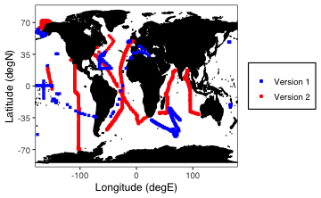

```r
YK <- map_data("world")

fig_1 <- ggplot() +
    coord_cartesian(xlim = c(-179.5, 179.5), ylim = c(-89.5, 89.5), expand = F) +
  labs(y = NULL) +
  xlab("Longitude (degE)") +
  ylab("Latitude (degN)") +
  scale_y_continuous(breaks=c(-70,-35, 0, 35, 70)) +
  geom_polygon(data = YK, aes(x=long, y = lat, group = group), color = "black", fill = "black") +
  geom_point(data = drop_na(dataPOM_all_ver2_surface_binned_1deg,POCavg_uM,PONavg_uM,POPavg_nM),
             mapping = aes(x = Longitude, y = Latitude, color="r"),
             size = 1.0,
             shape = 15) +
  geom_point(data = drop_na(dataPOM_all_ver1_surface_binned_1deg,POCavg_uM,PONavg_uM,POPavg_nM),
             mapping = aes(x = Longitude, y = Latitude, color = "b"),
             size = 1.0,
             shape = 15) +
  scale_colour_manual(name = "group", values=c("b" = "blue", "r"="red"), labels=c("b"="Version 1", "r"="Version 2")) +
  theme_bw(base_size = 10, base_family = "Helvetica") +
  theme(legend.key.size = unit(0.5, "cm"),
        legend.title = element_blank(), legend.background = element_rect(colour = 'black', fill = 'white', linetype='solid')) +
  theme(panel.border = element_rect(color = "black"), panel.grid.major = element_blank(), panel.grid.minor = element_blank())

fig_1
ggsave("Figures/Fig1.pdf",width = 8, height = 5)
```

### Figure 2abc. Make historgram of locations sampled (latitude/longitude/Basin) for surface CNP paired samples

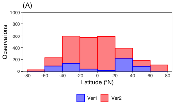

```r
fig2a_count <- ggplot() +
  geom_histogram(data = drop_na(dataPOM_all_ver1_ver2_combined_surface,
                                POCavg_uM,
                                PONavg_uM,
                                POPavg_nM),
                 mapping = aes(x = Latitude,
                               y = (..count..),
                               fill = forcats::fct_rev(Version),
                               color = forcats::fct_rev(Version)),
                 binwidth = 20,
                 boundary = 0,
                 alpha = 0.5) +
  ggtitle("(A)") +
  scale_fill_manual(values = c("red", "blue"), labels=c("Ver2", "Ver1")) +
  scale_color_manual(values = c("red", "blue"), labels=c("Ver2", "Ver1")) +
  xlab("Latitude (°N)") +
  ylab("Observations") +
  coord_cartesian(xlim = c(-85,85),ylim = c(0, 1000)) +
  scale_x_continuous(breaks= seq(from = -80, to = 80, by = 20), expand = c(0,0)) +
  scale_y_continuous(breaks= seq(from = 0, to = 1000, by = 200), expand = c(0,0)) +
  guides(fill = guide_legend(reverse = T), color = guide_legend(reverse = T)) +
  theme_bw(base_size = 10, base_family = "Helvetica") +
  theme(legend.position = "bottom", legend.box = "horizontal",legend.key.size = unit(0.5, "cm"),
        legend.title = element_blank()) +
  theme(panel.border = element_rect(color = "black"), panel.grid.major = element_blank(), panel.grid.minor = element_blank())

fig2a_count
```

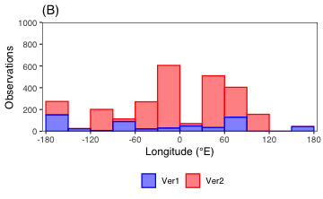

```r
fig2b_count <- ggplot() +
  geom_histogram(data = drop_na(dataPOM_all_ver1_ver2_combined_surface,
                                POCavg_uM,
                                PONavg_uM,
                                POPavg_nM),
                 mapping = aes(x = Longitude,
                               y = (..count..),
                               fill = forcats::fct_rev(Version),
                               color = forcats::fct_rev(Version)),
                 binwidth = 30,
                 boundary = 0,
                 alpha = 0.5) +
  ggtitle("(B)") +
  scale_fill_manual(values = c("red", "blue"), labels=c("Ver2", "Ver1")) +
  scale_color_manual(values = c("red", "blue"), labels=c("Ver2", "Ver1")) +
  xlab("Longitude (°E)") +
  ylab("Observations") +
  coord_cartesian(xlim = c(-185,185),ylim = c(0, 1000)) +
  scale_x_continuous(breaks= seq(from = -180, to = 180, by = 60), expand = c(0,0)) +
  scale_y_continuous(breaks= seq(from = 0, to = 1000, by = 200), expand = c(0,0)) +
  guides(fill = guide_legend(reverse = T), color = guide_legend(reverse = T)) +
  theme_bw(base_size = 10, base_family = "Helvetica") +
  theme(legend.position = "bottom", legend.box = "horizontal",legend.key.size = unit(0.5, "cm"),
        legend.title = element_blank()) +
  theme(panel.border = element_rect(color = "black"), panel.grid.major = element_blank(), panel.grid.minor = element_blank())

fig2b_count
```

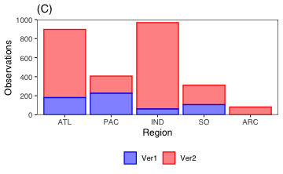

```r
fig2c_count <- ggplot(data = drop_na(dataPOM_all_ver1_ver2_combined_surface,
                      POCavg_uM,
                      PONavg_uM,
                      POPavg_nM) %>% filter(Region != 0),
                 aes(x = Region,  y = (..count..), fill = forcats::fct_rev(Version),
                     color = forcats::fct_rev(Version))) +
          geom_bar(stat="count", alpha = 0.5, size = 0.5) +
          ylab("") +
          # ylab("% of dataset") +
          # facet_wrap(~Version) +
  ggtitle("(C)") +
  scale_fill_manual(values = c("red", "blue"), labels=c("Ver2", "Ver1")) +
  scale_color_manual(values = c("red", "blue"), labels=c("Ver2", "Ver1")) +
  theme_bw(base_size = 10, base_family = "Helvetica") +
  coord_cartesian(ylim = c(0, 1000)) +
  scale_y_continuous(breaks= seq(from = 0, to = 1000, by = 200), expand = c(0,0)) +
  scale_x_discrete(labels = c('1' = 'ATL', '2' = 'PAC', '3' = 'IND', '4' = 'ARC', '5' = 'SO')) +
  ylab("Observations") +
  guides(fill = guide_legend(reverse = T), color = guide_legend(reverse = T)) +
  theme(legend.position = "bottom", legend.box = "horizontal",legend.key.size = unit(0.5, "cm"),
        legend.title = element_blank()) +
  theme(panel.border = element_rect(color = "black"), panel.grid.major = element_blank(), panel.grid.minor = element_blank()) +   theme(strip.background = element_blank(), strip.text.x = element_blank())
fig2c_count
```

```r
## visualize together
fig_left_grob <- ggplotGrob(fig2a_count)
fig_middle_grob <- ggplotGrob(fig2b_count)
fig_right_grob <- ggplotGrob(fig2c_count)
gg <- ggplot() +
  coord_equal(xlim = c(1, 14.5), ylim = c(1, 6), expand = F) +
    annotation_custom(fig_left_grob,
                      xmin = 1, xmax = 5.5, ymin = 1, ymax = 6) +
      annotation_custom(fig_middle_grob,
                      xmin = 5.5, xmax = 10, ymin = 1, ymax = 6) +
        annotation_custom(fig_right_grob,
                      xmin = 10, xmax = 14.5, ymin = 1, ymax = 6) +
    theme(panel.border = element_blank())
gg
```

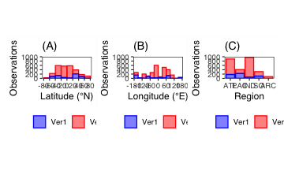

```r
ggsave("Figures/Fig2abc_latlon_count.pdf",
        width = 8, # The width of the plot in inches
        height = 5)
```

### Figure 3. Make historgram of surface CNPO2 for paired samples

```r
dataPOM_all_ver1_surface <- dataPOM_all_ver1_surface %>% dplyr::mutate(CP = POCavg_uM/POPavg_nM*1000,
                                                                       NP = PONavg_uM/POPavg_nM*1000,
                                                                       CN = POCavg_uM/PONavg_uM,
                                                                       RQ = PCODavg_uM/POCavg_uM,
                                                                       O2_P = PCODavg_uM/POPavg_nM*1000)
dataPOM_all_ver2_surface <- dataPOM_all_ver2_surface %>% dplyr::mutate(CP = POCavg_uM/POPavg_nM*1000,
                                                                       NP = PONavg_uM/POPavg_nM*1000,
                                                                       CN = POCavg_uM/PONavg_uM,
                                                                       RQ = PCODavg_uM/POCavg_uM,
                                                                       O2_P = PCODavg_uM/POPavg_nM*1000)
```

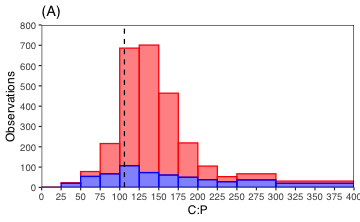

```r
breaks = c(0,25,50,75,100,125,150,175,200,225, 250,300,400)
fig3a_count <- ggplot() +
  geom_histogram(data = drop_na(dataPOM_all_ver1_ver2_combined_surface,
                                POCavg_uM,
                                PONavg_uM,
                                POPavg_nM),
                 mapping = aes(x = POCavg_uM/POPavg_nM*1000,
                               y = (..count..),
                               color = forcats::fct_rev(Version),
                               fill = forcats::fct_rev(Version)),
                 # binwidth = 25,
                 # boundary = 0,
                 breaks = breaks,
                 alpha = .5,
                 size = 0.5) +
  geom_vline(xintercept = 106, linetype="dashed",
                color = "black", size=0.5) +
  ggtitle("(A)") +
  scale_fill_manual(values = c("red", "blue"), labels=c("Ver2", "Ver1")) +
  scale_color_manual(values = c("red", "blue"), labels=c("Ver2", "Ver1")) +
  xlab("C:P") +
  ylab("Observations") +
  coord_cartesian(xlim = c(0,400), ylim = c(0, 800)) +
  scale_x_continuous(breaks= seq(from = 0, to = 400, by = 25), expand = c(0,0)) +
  scale_y_continuous(breaks= seq(from = 0, to = 800, by = 100), expand = c(0,0)) +
  guides(fill = guide_legend(reverse = T), color = guide_legend(reverse = T)) +
  theme_bw(base_size = 10, base_family = "Helvetica") +
  theme(legend.position = "none") +
  theme(panel.border = element_rect(color = "black"), panel.grid.major = element_blank(), panel.grid.minor = element_blank())

fig3a_count
```

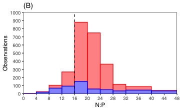

```r
breaks = c(0,4,8,12,16,20,24,28,32,40,48,56)
fig3b_count <- ggplot() +
  geom_histogram(data = drop_na(dataPOM_all_ver1_ver2_combined_surface,
                                POCavg_uM,
                                PONavg_uM,
                                POPavg_nM),
                 mapping = aes(x = PONavg_uM/POPavg_nM*1000,
                               y = (..count..),
                               color = forcats::fct_rev(Version),
                               fill = forcats::fct_rev(Version)),
                 breaks = breaks,
                 # binwidth = 4,
                 # boundary = 0,
                 alpha = .5,
                 size = 0.5) +
  geom_vline(xintercept = 16, linetype="dashed",
                color = "black", size=0.5) +
  ggtitle("(B)") +
  scale_fill_manual(values = c("red", "blue"), labels=c("Ver2", "Ver1")) +
  scale_color_manual(values = c("red", "blue"), labels=c("Ver2", "Ver1")) +
  xlab("N:P") +
  ylab("Observations") +
  coord_cartesian(xlim = c(0,48), ylim = c(0, 1000)) +
  scale_x_continuous(breaks= seq(from = 0, to = 48, by = 4), expand = c(0,0)) +
  scale_y_continuous(breaks= seq(from = 0, to = 1000, by = 100), expand = c(0,0)) +
  guides(fill = guide_legend(reverse = T), color = guide_legend(reverse = T)) +
  theme_bw(base_size = 10, base_family = "Helvetica") +
  theme(legend.position = "none") +
  theme(panel.border = element_rect(color = "black"), panel.grid.major = element_blank(), panel.grid.minor = element_blank())

fig3b_count
```

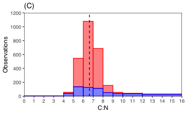

```r
breaks = c(0,4,5,6,7,8,9,10,12,16)
fig3c_count <- ggplot() +
  geom_histogram(data = drop_na(dataPOM_all_ver1_ver2_combined_surface,
                                POCavg_uM,
                                PONavg_uM,
                                POPavg_nM),
                 mapping = aes(x = POCavg_uM/PONavg_uM,
                               y = (..count..),
                               color = forcats::fct_rev(Version),
                               fill = forcats::fct_rev(Version)),
                 # binwidth = 1,
                 # boundary = 0,
                 breaks = breaks,
                 alpha = .5,
                 size = 0.5) +
  geom_vline(xintercept = 106/16, linetype="dashed",
                color = "black", size=0.5) +
  ggtitle("(C)") +
  scale_fill_manual(values = c("red", "blue"), labels=c("Ver2", "Ver1")) +
  scale_color_manual(values = c("red", "blue"), labels=c("Ver2", "Ver1")) +
  xlab("C:N") +
  ylab("Observations") +
  coord_cartesian(xlim = c(0,16), ylim = c(0, 1200)) +
  scale_x_continuous(breaks= seq(from = 0, to = 16, by = 1), expand = c(0,0)) +
  scale_y_continuous(breaks= seq(from = 0, to = 1200, by = 200), expand = c(0,0)) +
  guides(fill = guide_legend(reverse = T), color = guide_legend(reverse = T)) +
  theme_bw(base_size = 10, base_family = "Helvetica") +
  theme(legend.position = "none") +
  theme(panel.border = element_rect(color = "black"), panel.grid.major = element_blank(), panel.grid.minor = element_blank())

fig3c_count
```

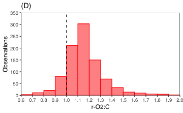

```r
breaks = c(0,0.2,0.4,0.6,0.7,0.8,0.9,1.0,1.1,1.2,1.3,1.4,1.5,1.6,1.7,1.8,1.9,2.0)
fig3d_count <- ggplot() +
  geom_histogram(data = drop_na(dataPOM_all_ver1_ver2_combined_surface,
                                POCavg_uM,
                                PONavg_uM,
                                POPavg_nM),
                 mapping = aes(x = PCODavg_uM/POCavg_uM,
                               y = (..count..),
                               color = forcats::fct_rev(Version),
                               fill = forcats::fct_rev(Version)),
                 # binwidth = 1,
                 # boundary = 0,
                 breaks = breaks,
                 alpha = .5,
                 size = 0.5) +
  geom_vline(xintercept = 1.0, linetype="dashed",
                color = "black", size=0.5) +
  ggtitle("(D)") +
  scale_fill_manual(values = c("red", "blue"), labels=c("Ver2", "Ver1")) +
  scale_color_manual(values = c("red", "blue"), labels=c("Ver2", "Ver1")) +
  xlab("r-O2:C") +
  ylab("Observations") +
  coord_cartesian(xlim = c(0.6,2.0), ylim = c(0, 350)) +
  scale_x_continuous(breaks= seq(from = 0.6, to = 2.0, by = 0.1), expand = c(0,0)) +
  scale_y_continuous(breaks= seq(from = 0, to = 350, by = 50), expand = c(0,0)) +
  guides(fill = guide_legend(reverse = T), color = guide_legend(reverse = T)) +
  theme_bw(base_size = 10, base_family = "Helvetica") +
  theme(legend.position = "none") +
  theme(panel.border = element_rect(color = "black"), panel.grid.major = element_blank(), panel.grid.minor = element_blank())

fig3d_count
```

```r
## visualize together
fig_topleft_grob <- ggplotGrob(fig3a_count)
fig_topright_grob <- ggplotGrob(fig3b_count)
fig_bottomleft_grob <- ggplotGrob(fig3c_count)
fig_bottomright_grob <- ggplotGrob(fig3d_count)
gg <- ggplot() +
  coord_equal(xlim = c(1, 14.5), ylim = c(1, 11), expand = F) +
    annotation_custom(fig_topleft_grob,
                      xmin = 1, xmax = 7.75, ymin = 6, ymax = 11) +
      annotation_custom(fig_topright_grob,
                      xmin = 7.75, xmax = 14.5, ymin = 6, ymax = 11) +
      annotation_custom(fig_bottomleft_grob,
                      xmin = 1, xmax = 7.75, ymin = 1, ymax = 6) +
      annotation_custom(fig_bottomright_grob,
                      xmin = 7.75, xmax = 14.5, ymin = 1, ymax = 6) +
    theme(panel.border = element_blank())
gg
```

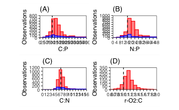

```r
ggsave("Figures/Fig3abcd_CNP_count.pdf",
        width = 10, # The width of the plot in inches
        height = 6.25)
```